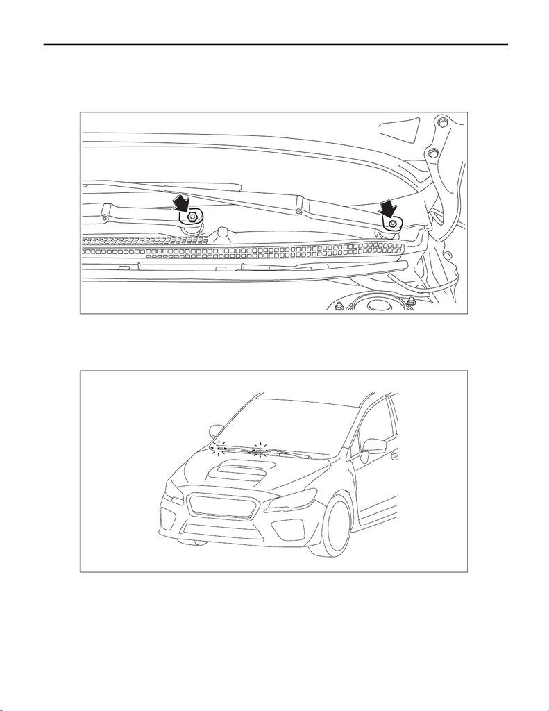

WW-19

Front Wiper Arm

WIPER AND WASHER SYSTEMS

7. Front Wiper Arm

A: REMOVAL

1) Remove the cover - windshield wiper arm.

2) Remove the nuts, and remove the arm assembly - windshield wiper.

B: INSTALLATION

1) Install the arm assembly - windshield wiper.

(1) Assemble the arm assembly - windshield wiper so that the blade assembly - windshield wiper is

aligned to the ceramic print point mark of the windshield glass.

WW-00827

WW-01166

[figure not shown]

WW-20

Front Wiper Arm

WIPER AND WASHER SYSTEMS

(2) Tighten the arm assembly - windshield wiper to specified torque and install the cap.

Tightening torque:

26 N·m (2.7 kgf-m, 19.2 ft-lb)

2) Check the position of windshield wiper. <Ref. to WW-20, ADJUSTMENT, Front Wiper Arm.>

C: ADJUSTMENT

1) Operate the windshield wiper once.

2) Check that the wiper blade is aligned with the point mark.

3) If the wiper blade is not aligned with the point mark, perform the removal and installation of the windshield

wiper. <Ref. to WW-19, REMOVAL, Front Wiper Arm.>

WW-00827

WW-01166